# Lesson 4: Data

Daniel Stoxreiter

*all code was generated in collaboration with colleagues of the R course*

```r
# Loading the bagdad-london--finalRestat.dta data
library(haven)
bagdad_london_finalRestat <- read_dta("~/R_course/R-univie/lession4/Bosker_Data/bagdad-london--finalRestat.dta")
```

# What is the chronological extent of this data?

```r
# returns the earliest year of the database
min(bagdad_london_finalRestat$year)
```

```
## [1] 800
```

```r
# returns the latest year of the database
max(bagdad_london_finalRestat$year)
```

```
## [1] 1800
```

```r
# returns a summary of the database
summary(bagdad_london_finalRestat$year)
```

```
##    Min. 1st Qu.  Median    Mean 3rd Qu.    Max.
##     800    1000    1300    1300    1600    1800
```

# What periods can it be divided into? How can we do that?

The data can be devided into early medieval period, late medieval period, early modern period and late modern period. As an example the data is divided into oly two periods: Medieval and Modern.

```r
# Medieval period which is everything in the database dated prior and equal 1500.
Medieval.bagdad.sub <- subset(bagdad_london_finalRestat,  bagdad_london_finalRestat$year <= 1500)
head(Medieval.bagdad.sub, 10)
```

| indicator | city | country | year | arab_peninsula | latitude | longitude | citypop_le10 | citypop_le5 | sea | river | hub_3rr | rom_road_nohub | caravan_hub | caravan_nohub | elevation_m | rugg10 | bishop | archbishop | capital | university | muslim | me_na | muslim_holy_city | plundered | soilquality | commune | ecozones | free_prince_dls | total_pop_country | … |
| --- | --- | --- | --- | --- | --- | --- | --- | --- | --- | --- | --- | --- | --- | --- | --- | --- | --- | --- | --- | --- | --- | --- | --- | --- | --- | --- | --- | --- | --- | --- |
| 1 | Graz | Austria | 800 | 0 | 47.067 | 15.450 | 0 | 0 | 0 | 1 | 0 | 1 | 0 | 0 | 366 | 103.6200 | 0 | 0 | 0 | 0 | 0 | 0 | 0 | 0 | 0.414 | 0 | 6 | 0 | 500 | … |
| 2 | Innsbruck | Austria | 800 | 0 | 47.267 | 11.400 | 0 | 0 | 0 | 1 | 1 | 0 | 0 | 0 | 562 | 559.4500 | 0 | 0 | 0 | 0 | 0 | 0 | 0 | 0 | 0.020 | 0 | 6 | 0 | 500 | … |
| 3 | Klagenfurt | Austria | 800 | 0 | 46.625 | 14.305 | 0 | 0 | 0 | 1 | 0 | 0 | 0 | 0 | 441 | 99.8080 | 0 | 0 | 0 | 0 | 0 | 0 | 0 | 0 | 0.384 | 0 | 6 | 0 | 500 | … |
| 4 | Linz | Austria | 800 | 0 | 48.300 | 14.300 | 0 | 0 | 0 | 1 | 0 | 1 | 0 | 0 | 258 | 141.2700 | 0 | 0 | 0 | 0 | 0 | 0 | 0 | 0 | 0.660 | 0 | 4 | 0 | 500 | … |
| 5 | Salzburg | Austria | 800 | 0 | 47.800 | 13.033 | 0 | 0 | 0 | 1 | 1 | 0 | 0 | 0 | 427 | 208.7200 | 0 | 1 | 0 | 0 | 0 | 0 | 0 | 0 | 0.326 | 0 | 6 | 0 | 500 | … |
| 6 | Wien (Vienna) | Austria | 800 | 0 | 48.200 | 16.367 | 0 | 0 | 0 | 1 | 1 | 0 | 0 | 0 | 170 | 51.1590 | 0 | 0 | 0 | 0 | 0 | 0 | 0 | 0 | 0.978 | 0 | 4 | 0 | 500 | … |
| 7 | Aalst (Alost) | Belgium | 800 | 0 | 50.933 | 4.033 | 0 | 0 | 0 | 1 | 0 | 0 | 0 | 0 | 17 | 15.2810 | 0 | 0 | 0 | 0 | 0 | 0 | 0 | 0 | 0.718 | 0 | 4 | 0 | 300 | … |
| 8 | Antwerpen (Anvers, Antwerp) | Belgium | 800 | 0 | 51.217 | 4.417 | 0 | 0 | 1 | 1 | 0 | 0 | 0 | 0 | 3 | 4.1151 | 0 | 0 | 0 | 0 | 0 | 0 | 0 | 0 | 0.563 | 0 | 4 | 0 | 300 | … |
| 9 | Brugge (bruges) | Belgium | 800 | 0 | 51.217 | 3.233 | 0 | 0 | 1 | 1 | 0 | 0 | 0 | 0 | 2 | 3.1619 | 0 | 0 | 0 | 0 | 0 | 0 | 0 | 0 | 0.705 | 0 | 4 | 0 | 300 | … |
| 10 | Bruxelles (brussels) | Belgium | 800 | 0 | 50.833 | 4.333 | 0 | 0 | 0 | 0 | 0 | 1 | 0 | 0 | 62 | 29.4160 | 0 | 0 | 0 | 0 | 0 | 0 | 0 | 0 | 0.718 | 0 | 4 | 0 | 300 | … |

```r
tail(Medieval.bagdad.sub, 10)
```

| indicator | city | country | year | arab_peninsula | latitude | longitude | citypop_le10 | citypop_le5 | sea | river | hub_3rr | rom_road_nohub | caravan_hub | caravan_nohub | elevation_m | rugg10 | bishop | archbishop | capital | university | muslim | me_na | muslim_holy_city | plundered | soilquality | commune | ecozones | free_prince_dls | total_pop_country | … |
| --- | --- | --- | --- | --- | --- | --- | --- | --- | --- | --- | --- | --- | --- | --- | --- | --- | --- | --- | --- | --- | --- | --- | --- | --- | --- | --- | --- | --- | --- | --- |
| 784 | Medina al-Fayyum (Madinat al-Fayyum, al-Faiyum, Crocodilopolis) | Egypt | 1500 | 0 | 29.30 | 30.83 | 15 | 15 | 0 | 1 | 0 | 0 | 0 | 0 | 15 | 5.5581 | 1 | 0 | 0 | 0 | 1 | 1 | 0 | 0 | 0.006 | 0 | 1 | 0 | 4000 | … |
| 785 | Mansura (al-Mansura) | Egypt | 1500 | 0 | 31.07 | 31.68 | 14 | 14 | 0 | 1 | 0 | 0 | 0 | 0 | 8 | 2.4285 | 1 | 0 | 0 | 0 | 1 | 1 | 0 | 0 | 0.024 | 0 | 1 | 0 | 4000 | … |
| 786 | Bilbeis (Bilbays, Bilbis, Bulbays, Phelbes) | Egypt | 1500 | 0 | 30.42 | 31.57 | 10 | 10 | 0 | 1 | 0 | 0 | 0 | 0 | 17 | 6.4112 | 0 | 0 | 0 | 0 | 1 | 1 | 0 | 0 | 0.003 | 0 | 1 | 0 | 4000 | … |
| 787 | Damanhur (Hermeopolis parva, Hermeopolis mikra) | Egypt | 1500 | 0 | 31.05 | 30.47 | 10 | 10 | 0 | 0 | 0 | 1 | 0 | 0 | 16 | 3.5173 | 1 | 0 | 0 | 0 | 1 | 1 | 0 | 0 | 0.092 | 0 | 1 | 0 | 4000 | … |
| 788 | Menuf (Manuf, Manuf al Ulya, Minuf, Onouphisanou, Onouphis) | Egypt | 1500 | 0 | 30.46 | 30.92 | 10 | 10 | 0 | 0 | 0 | 0 | 0 | 0 | 4 | 4.6103 | 0 | 0 | 0 | 0 | 1 | 1 | 0 | 0 | 0.005 | 0 | 1 | 0 | 4000 | … |
| 789 | Asyut (Isiu) | Egypt | 1500 | 0 | 27.18 | 31.17 | 10 | 10 | 0 | 1 | 0 | 0 | 0 | 1 | 47 | 61.5050 | 1 | 0 | 0 | 0 | 1 | 1 | 0 | 0 | 0.004 | 0 | 1 | 0 | 4000 | … |
| 790 | Aswan (Uswan, Syene, Swenet) | Egypt | 1500 | 0 | 24.08 | 32.90 | 0 | 0 | 0 | 1 | 0 | 0 | 0 | 1 | 95 | 34.0500 | 1 | 0 | 0 | 0 | 1 | 1 | 0 | 0 | 0.002 | 0 | 1 | 0 | 4000 | … |
| 791 | Kina (Kuna, Kaine, Qena, Maximanopolis) | Egypt | 1500 | 0 | 32.72 | 26.17 | 10 | 10 | 0 | 1 | 0 | 0 | 0 | 1 | 66 | 27.0670 | 1 | 0 | 0 | 0 | 1 | 1 | 0 | 0 | 0.003 | 0 | 1 | 0 | 4000 | … |
| 792 | Qalyub (Qaliub, Kalyub) | Egypt | 1500 | 0 | 30.20 | 31.20 | 0 | 0 | 0 | 1 | 0 | 0 | 0 | 0 | 29 | 8.8520 | 0 | 0 | 0 | 0 | 1 | 1 | 0 | 0 | 0.010 | 0 | 1 | 0 | 4000 | … |
| 793 | Tanta (Taya) | Egypt | 1500 | 0 | 30.78 | 31.00 | 0 | 0 | 0 | 0 | 0 | 0 | 0 | 0 | 15 | 4.7635 | 1 | 0 | 0 | 0 | 1 | 1 | 0 | 0 | 0.018 | 0 | 1 | 0 | 4000 | … |

```r
# Modern period which is everything after 1500.
Modern.bagdad.sub <- subset(bagdad_london_finalRestat,  bagdad_london_finalRestat$year > 1500)
head(Modern.bagdad.sub, 10)
```

| indicator | city | country | year | arab_peninsula | latitude | longitude | citypop_le10 | citypop_le5 | sea | river | hub_3rr | rom_road_nohub | caravan_hub | caravan_nohub | elevation_m | rugg10 | bishop | archbishop | capital | university | muslim | me_na | muslim_holy_city | plundered | soilquality | commune | ecozones | free_prince_dls | total_pop_country | … |
| --- | --- | --- | --- | --- | --- | --- | --- | --- | --- | --- | --- | --- | --- | --- | --- | --- | --- | --- | --- | --- | --- | --- | --- | --- | --- | --- | --- | --- | --- | --- |
| 1 | Graz | Austria | 1600 | 0 | 47.067 | 15.450 | 0 | 8 | 0 | 1 | 0 | 1 | 0 | 0 | 366 | 103.6200 | 0 | 0 | 0 | 1 | 0 | 0 | 0 | 0 | 0.414 | 1 | 6 | 0 | 2500 | … |
| 2 | Innsbruck | Austria | 1600 | 0 | 47.267 | 11.400 | 0 | 6 | 0 | 1 | 1 | 0 | 0 | 0 | 562 | 559.4500 | 0 | 0 | 0 | 0 | 0 | 0 | 0 | 0 | 0.020 | 1 | 6 | 0 | 2500 | … |
| 3 | Klagenfurt | Austria | 1600 | 0 | 46.625 | 14.305 | 0 | 0 | 0 | 1 | 0 | 0 | 0 | 0 | 441 | 99.8080 | 0 | 0 | 0 | 0 | 0 | 0 | 0 | 0 | 0.384 | 1 | 6 | 0 | 2500 | … |
| 4 | Linz | Austria | 1600 | 0 | 48.300 | 14.300 | 0 | 0 | 0 | 1 | 0 | 1 | 0 | 0 | 258 | 141.2700 | 0 | 0 | 0 | 0 | 0 | 0 | 0 | 0 | 0.660 | 1 | 4 | 0 | 2500 | … |
| 5 | Salzburg | Austria | 1600 | 0 | 47.800 | 13.033 | 0 | 9 | 0 | 1 | 1 | 0 | 0 | 0 | 427 | 208.7200 | 0 | 1 | 0 | 0 | 0 | 0 | 0 | 0 | 0.326 | 1 | 6 | 0 | 2500 | … |
| 6 | Wien (Vienna) | Austria | 1600 | 0 | 48.200 | 16.367 | 50 | 50 | 0 | 1 | 1 | 0 | 0 | 0 | 170 | 51.1590 | 1 | 0 | 1 | 1 | 0 | 0 | 0 | 0 | 0.978 | 1 | 4 | 0 | 2500 | … |
| 7 | Aalst (Alost) | Belgium | 1600 | 0 | 50.933 | 4.033 | 0 | 7 | 0 | 1 | 0 | 0 | 0 | 0 | 17 | 15.2810 | 0 | 0 | 0 | 0 | 0 | 0 | 0 | 0 | 0.718 | 1 | 4 | 0 | 1500 | … |
| 8 | Antwerpen (Anvers, Antwerp) | Belgium | 1600 | 0 | 51.217 | 4.417 | 47 | 47 | 1 | 1 | 0 | 0 | 0 | 0 | 3 | 4.1151 | 1 | 0 | 0 | 0 | 0 | 0 | 0 | 0 | 0.563 | 1 | 4 | 0 | 1500 | … |
| 9 | Brugge (bruges) | Belgium | 1600 | 0 | 51.217 | 3.233 | 27 | 27 | 0 | 1 | 0 | 0 | 0 | 0 | 2 | 3.1619 | 1 | 0 | 0 | 0 | 0 | 0 | 0 | 0 | 0.705 | 1 | 4 | 0 | 1500 | … |
| 10 | Bruxelles (brussels) | Belgium | 1600 | 0 | 50.833 | 4.333 | 50 | 50 | 0 | 0 | 0 | 1 | 0 | 0 | 62 | 29.4160 | 0 | 0 | 1 | 0 | 0 | 0 | 0 | 0 | 0.718 | 1 | 4 | 0 | 1500 | … |

```r
tail(Modern.bagdad.sub, 10)
```

| indicator | city | country | year | arab_peninsula | latitude | longitude | citypop_le10 | citypop_le5 | sea | river | hub_3rr | rom_road_nohub | caravan_hub | caravan_nohub | elevation_m | rugg10 | bishop | archbishop | capital | university | muslim | me_na | muslim_holy_city | plundered | soilquality | commune | ecozones | free_prince_dls | total_pop_country | … |
| --- | --- | --- | --- | --- | --- | --- | --- | --- | --- | --- | --- | --- | --- | --- | --- | --- | --- | --- | --- | --- | --- | --- | --- | --- | --- | --- | --- | --- | --- | --- |
| 784 | Medina al-Fayyum (Madinat al-Fayyum, al-Faiyum, Crocodilopolis) | Egypt | 1800 | 0 | 29.30 | 30.83 | 15 | 15 | 0 | 1 | 0 | 0 | 0 | 0 | 15 | 5.5581 | 1 | 0 | 0 | 0 | 1 | 1 | 0 | 0 | 0.006 | 0 | 1 | 0 | 3500 | … |
| 785 | Mansura (al-Mansura) | Egypt | 1800 | 0 | 31.07 | 31.68 | 14 | 14 | 0 | 1 | 0 | 0 | 0 | 0 | 8 | 2.4285 | 1 | 0 | 0 | 0 | 1 | 1 | 0 | 0 | 0.024 | 0 | 1 | 0 | 3500 | … |
| 786 | Bilbeis (Bilbays, Bilbis, Bulbays, Phelbes) | Egypt | 1800 | 0 | 30.42 | 31.57 | 10 | 10 | 0 | 1 | 0 | 0 | 0 | 0 | 17 | 6.4112 | 0 | 0 | 0 | 0 | 1 | 1 | 0 | 0 | 0.003 | 0 | 1 | 0 | 3500 | … |
| 787 | Damanhur (Hermeopolis parva, Hermeopolis mikra) | Egypt | 1800 | 0 | 31.05 | 30.47 | 10 | 10 | 0 | 0 | 0 | 1 | 0 | 0 | 16 | 3.5173 | 1 | 0 | 0 | 0 | 1 | 1 | 0 | 0 | 0.092 | 0 | 1 | 0 | 3500 | … |
| 788 | Menuf (Manuf, Manuf al Ulya, Minuf, Onouphisanou, Onouphis) | Egypt | 1800 | 0 | 30.46 | 30.92 | 10 | 10 | 0 | 0 | 0 | 0 | 0 | 0 | 4 | 4.6103 | 0 | 0 | 0 | 0 | 1 | 1 | 0 | 0 | 0.005 | 0 | 1 | 0 | 3500 | … |
| 789 | Asyut (Isiu) | Egypt | 1800 | 0 | 27.18 | 31.17 | 15 | 15 | 0 | 1 | 0 | 0 | 0 | 1 | 47 | 61.5050 | 1 | 0 | 0 | 0 | 1 | 1 | 0 | 0 | 0.004 | 0 | 1 | 0 | 3500 | … |
| 790 | Aswan (Uswan, Syene, Swenet) | Egypt | 1800 | 0 | 24.08 | 32.90 | 0 | 0 | 0 | 1 | 0 | 0 | 0 | 1 | 95 | 34.0500 | 1 | 0 | 0 | 0 | 1 | 1 | 0 | 0 | 0.002 | 0 | 1 | 0 | 3500 | … |
| 791 | Kina (Kuna, Kaine, Qena, Maximanopolis) | Egypt | 1800 | 0 | 32.72 | 26.17 | 15 | 15 | 0 | 1 | 0 | 0 | 0 | 1 | 66 | 27.0670 | 1 | 0 | 0 | 0 | 1 | 1 | 0 | 0 | 0.003 | 0 | 1 | 0 | 3500 | … |
| 792 | Qalyub (Qaliub, Kalyub) | Egypt | 1800 | 0 | 30.20 | 31.20 | 10 | 10 | 0 | 1 | 0 | 0 | 0 | 0 | 29 | 8.8520 | 0 | 0 | 0 | 0 | 1 | 1 | 0 | 0 | 0.010 | 0 | 1 | 0 | 3500 | … |
| 793 | Tanta (Taya) | Egypt | 1800 | 0 | 30.78 | 31.00 | 10 | 10 | 0 | 0 | 0 | 0 | 0 | 0 | 15 | 4.7635 | 1 | 0 | 0 | 0 | 1 | 1 | 0 | 0 | 0.018 | 0 | 1 | 0 | 3500 | … |

## Can you generate a cumulative graph of population over time, divided into these periods? (Hint: there should be one line for one period and another for another, etc.)

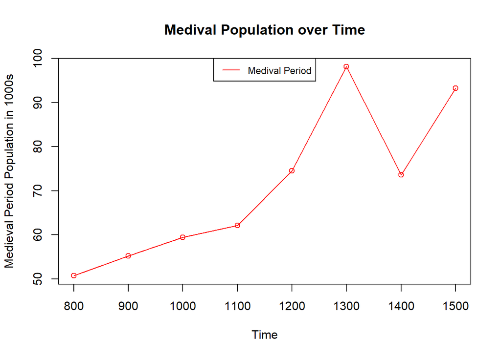

```r
# Medieval period which is everything in the database dated prior and equal 1500.
Medieval.bagdad.sub <- subset(bagdad_london_finalRestat, bagdad_london_finalRestat$year <= 1500)
# Modern period which is everything after 1500.
Modern.bagdad.sub <- subset(bagdad_london_finalRestat, bagdad_london_finalRestat$year > 1500)
# Creates a new dataframe for the Medieval period with three variables only (year, country and pop = population of the country)
data.frame.Medieval <- data.frame("year" = Medieval.bagdad.sub$year, "country" = Medieval.bagdad.sub$country, "pop" = Medieval.bagdad.sub$total_pop_country)
# Creates a new dataframe for the Modern period with three variables only (year, country and pop = population of the country)
data.frame.Modern <- data.frame("year" = Modern.bagdad.sub$year, "country" = Modern.bagdad.sub$country, "pop" = Modern.bagdad.sub$total_pop_country)
# Removes all duplicates from the dataset for the Medieval period
uniqueMedieval = unique(data.frame.Medieval[c("year", "country", "pop")])
# Creates a sum by aggregating the poulation of the country by year for the Medieval period.
aggMedieval = aggregate(uniqueMedieval$pop, by=list(Category=uniqueMedieval$year), FUN=sum)
# Removes all duplicates from the dataset for the Modern period
uniqueModern = unique(data.frame.Modern[c("year", "country", "pop")])
# Creates a sum by aggregating the poulation of the country by year for the Modern period.
aggModern = aggregate(uniqueModern$pop, by=list(Category=uniqueModern$year), FUN=sum)

# Plotting:
# Creates a single plot of the Medieval period population over time
plot(x = aggMedieval$Category, y = aggMedieval$x / 1000, type = "o", col="red", ylab = "Medieval Period Population in 1000s", xlab = "Time", main = "Medival Population over Time")
# Legend on top of the graph
legend("top", legend=c("Medival Period"),col=c("red"), lty = 1:2, cex=0.8)
```

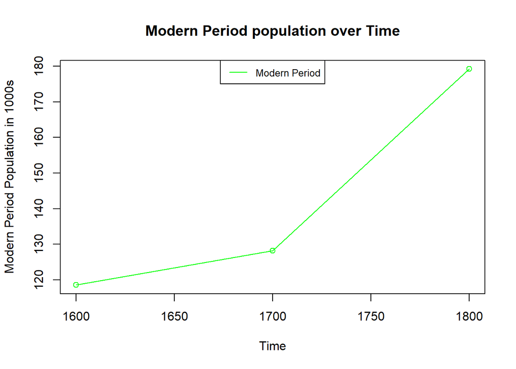

```r
plot(x = aggModern$Category, y = aggModern$x / 1000, type = "o", col="green", ylab = "Modern Period Population in 1000s", xlab = "Time", main = "Modern Period population over Time")
# Legend on top of the graph
legend("top", legend=c("Modern Period"),col=c("green"), lty = 1:2, cex=0.8)
```

## Combined graph of Medieval and the Modern period and their populaton over time

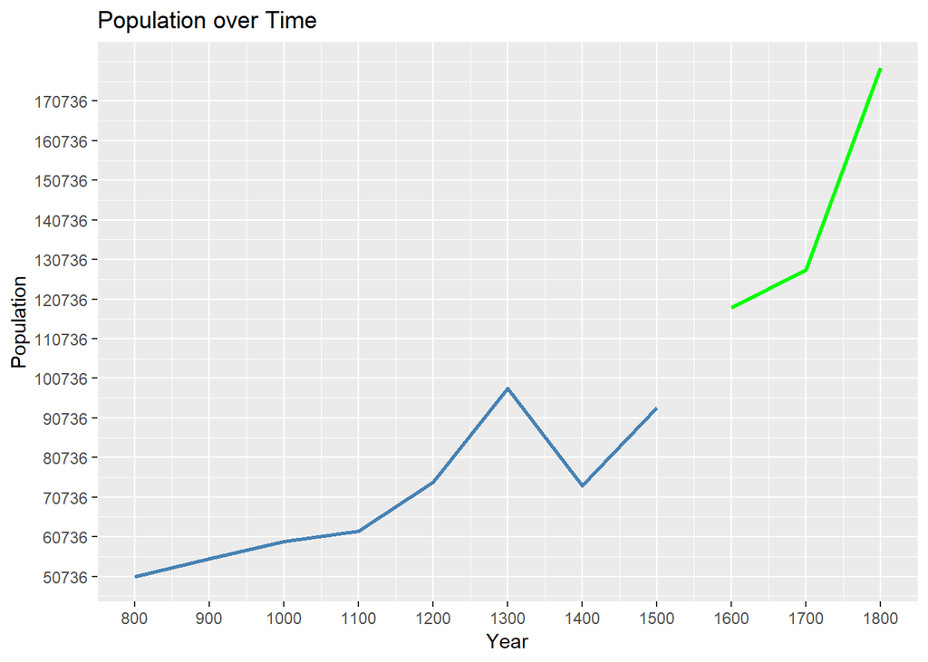

```r
medieval_population <- Medieval.bagdad.sub$citypop_le5
range_population_medieval <- range(Medieval.bagdad.sub$citypop_le5)
range_population_modern <- range(Modern.bagdad.sub$citypop_le5)
range_year_modern <- range(Modern.bagdad.sub$year)
years_medival_modern <- unique(bagdad_london_finalRestat$year)

library(ggplot2)
ggplot() +
  geom_line(data = aggMedieval, aes(y = aggMedieval$x, x= aggMedieval$Category), size=1, color ="steelblue") +
  geom_line(data= aggModern, aes(y = aggModern$x, x= aggModern$Category), size= 1, color ="green") +
  xlab("Year") + ylab("Population") +
  ggtitle("Population over Time") +
  scale_x_continuous(breaks =round(seq(min(years_medival_modern), max(years_medival_modern), by = 100),1)) +
    scale_y_continuous(breaks = round(seq(min(aggMedieval$x), max(aggModern$x), by =10000),1)) +
  scale_color_discrete(name="Period",  labels = c("Modern Population", "Medival Population"))
```

# North Africa and Europe?

Can you construct comparative graphs of population in North Africa and Europe (similar to what you did with the Morris dataset). Here you will need to sum up population!

```r
# creates a vectors with unique countries from the main database
unique_countries <- unique(bagdad_london_finalRestat$country)
# vectors of european countries only
Europevector <- c("Austria", "Ireland", "Belgium", "Czech rep.", "Denmark", "Finland", "France", "Germany", "Hungary", "Italy", "Netherlands", "Norway", "Poland", "Portugal", "Slovakia", "Spain", "Sweden", "UK", "Switzerland", "Greece", "Turkey", "Yugoslavia", "Albania", "Bulgaria", "Rumenia", "Luxemburg", "Malta")
# vector of north african countries only
NorthAfricavector <- c("Morocco", "Tunesia", "Lybia", "Egypt", "Syria")
# compares the main database with the Europevector and stores information in a new dataframe with values for countries that are in the Europevector only.
Europe.bagdad <- bagdad_london_finalRestat[bagdad_london_finalRestat$country %in% Europevector, ]
# compares the main database with the NorthAfricavector and stores information in a new dataframe with values for countries that are in the NorthAfricavector only.
NorthAfrica.bagdad <- bagdad_london_finalRestat[bagdad_london_finalRestat$country %in% NorthAfricavector, ]
```

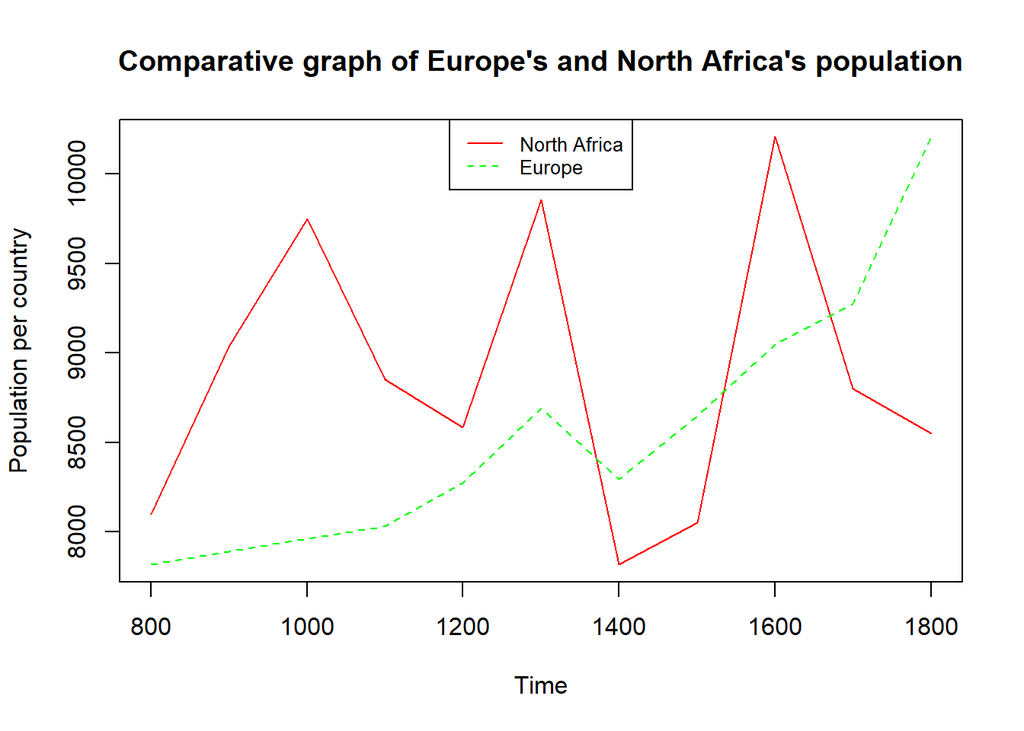

```r
# creates a new dataframe for european countries only with three variables (year, country and pop = population of the country)
data.frame.europe <- data.frame("year" = Europe.bagdad$year, "country" = Europe.bagdad$country, "pop" = Europe.bagdad$total_pop_country)
# creates a new dataframe for north african countries only with three variables (year, country and pop = population of the country)
data.frame.Africa <- data.frame("year" = NorthAfrica.bagdad$year, "country" = NorthAfrica.bagdad$country, "pop" = NorthAfrica.bagdad$total_pop_country)
# stores unique values of the columns year, country and pop and stores it in a dataframe
uniqueAfrica = unique(data.frame.Africa[c("year", "country", "pop")])
# creates a sum by aggregating the poulation of the country by year for north african countries.
aggAfrica = aggregate(uniqueAfrica$pop, by=list(Category=uniqueAfrica$year), FUN=sum)
# stores unique values of the columns year, country and pop and stores it in a dataframe
uniqueEurope = unique(data.frame.europe[c("year", "country", "pop")])
# creates a sum by aggregating the poulation of the country by year for european countries.
aggEurope = aggregate(uniqueEurope$pop, by=list(Category=uniqueEurope$year), FUN=sum)

#Plotting:
# comparative graphs of population in North Africa and Europe
plot(x = aggAfrica$Category, y = aggAfrica$x, type = "l", col="red", ylab = "Population per country", xlab = "Time", main = "Comparative graph of Europe's and North Africa's population")
par(new = TRUE)
plot(x = aggEurope$Category, y = aggEurope$x, type = "l", col="green", axes = FALSE, xlab = " ", ylab = " ", lty = 2)
legend("top", legend=c("North Africa", "Europe"),col=c("red", "green"), lty = 1:2, cex=0.8)
```

# Austro-Hungarian Empire

When did the Empire had the largest number of cities (based on the data set)?

```r
# Trials, not need for the answer

# Excludes all data before year 1500 from the database
habsburg <- bagdad_london_finalRestat[bagdad_london_finalRestat$year>=1500, c('city', 'country', 'year')]
# vector for countries to be excluded
exclude_countries <- c("Belgium", "Denmark", "Finland", "France", "Ireland", "Netherlands", "Norway", "Poland", "Portugal", "Spain", "Sweden", "UK", "Switzerland", "Greece", "Turkey", "Lebanon", "Israel", "Syria", "Iraq", "Egypt", "Lybia", "Tunesia", "Algeria", "Morocco", "Yemen", "Saudi Arabia","Oman", "Cyprus", "Luxemburg", "Malta", "Bulgaria")
# compares the data in the habsburg variable with the exclue_countries vector and keeps cuntries that are not in the exclude_countries vector only as a new database stored in the variable habsburg
habsburg <- habsburg[!(habsburg$country %in% exclude_countries), ]

# answer of the initial questions followes here:

library(dplyr)
# Habsburg at the 15 cent. Just country selection, but the way you do it is the same
habsburg_15_century <- c("Austria", "Spain", "France", "Italy","Belgium", "Netherlands", "Yugoslavia")
habsburg_frame_15 <- subset(bagdad_london_finalRestat, bagdad_london_finalRestat$year == 1500)
habsburg_frame_15 <- habsburg_frame_15[(habsburg_frame_15$country %in% habsburg_15_century), ]
habsburg_frame_15 %>% count(habsburg_frame_15$year)
```

| habsburg_frame_15$year | n |
| --- | --- |
| 1500 | 426 |

```r
# Habsburg at the 16 cent. Just country selection, but the way you do it is the same
habsburg_16_century <- c("Austria", "Hungary", "Italy", "Slovakia", "Czech rep.", "Rumenia", "Serbia", "Croatia", "Slovenia", "Galicia", "Ukraine", "Poland", "Luxemburg", "Belgium", "Germany", "France", "Spain", "Portugal", "Netherlands")
habsburg_frame_16 <- subset(bagdad_london_finalRestat, bagdad_london_finalRestat$year == 1600)
habsburg_frame_16 <- habsburg_frame_16[(habsburg_frame_16$country %in% habsburg_16_century), ]
habsburg_frame_16 %>% count(habsburg_frame_16$year)
```

| habsburg_frame_16$year | n |
| --- | --- |
| 1600 | 537 |

```r
#Habsburg at the 17 cent. Just country selection, but the way you do it is the same
habsburg_17_century <- c("Austria", "Hungary", "Italy", "Slovakia", "Czech rep.", "Rumenia", "Serbia", "Croatia", "Slovenia", "Ukraine", "Poland", "Luxemburg", "Belgium", "Netherlands")
habsburg_frame_17 <- subset(bagdad_london_finalRestat, bagdad_london_finalRestat$year == 1700)
habsburg_frame_17 <- habsburg_frame_17[(habsburg_frame_17$country %in% habsburg_17_century), ]
max_17 = nrow(habsburg_frame_17)
habsburg_frame_17 %>% count(habsburg_frame_17$year)
```

| habsburg_frame_17$year | n |
| --- | --- |
| 1700 | 249 |

```r
#Habsburg at the 18 cent. Just country selection, but the way you do it is the same
habsburg_18_century <- c("Austria", "Hungary", "Italy", "Slovakia", "Czech rep.", "Rumenia", "Yugoslavia", "Poland")
habsburg_frame_18 <- subset(bagdad_london_finalRestat, bagdad_london_finalRestat$year == 1800)
habsburg_frame_18 <- habsburg_frame_18[(habsburg_frame_18$country %in% habsburg_18_century), ]
# nrow(habsburg_frame_18) works also and is simpler
habsburg_frame_18 %>% count(habsburg_frame_18$year)
```

| habsburg_frame_18$year | n |
| --- | --- |
| 1800 | 222 |

## When was its population at the highest?

Well simplest solution, sum up every citi_pop_le5 and multiply by 1000.

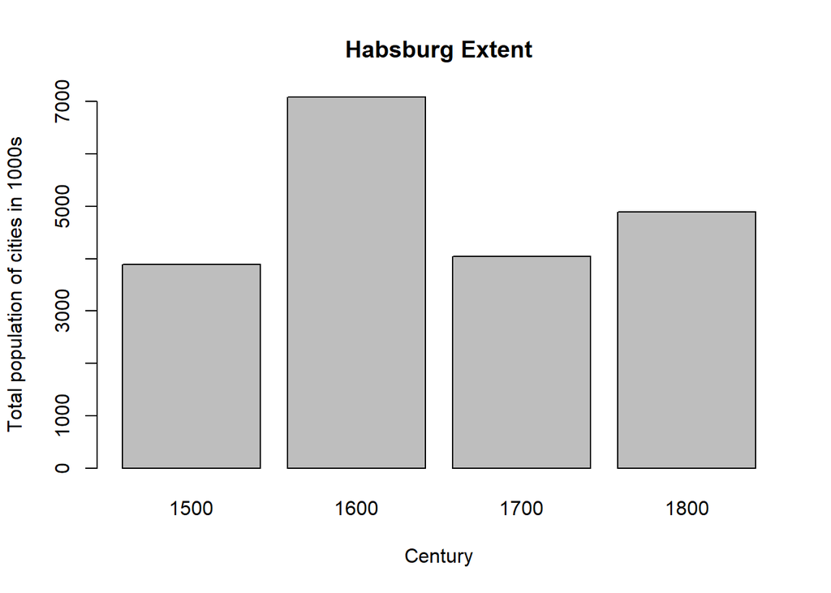

```r
# creating a sum for all the population based on cities of habsburg countries from specific centuries.
pop_h_15 <- sum(habsburg_frame_15$citypop_le5)
pop_h_16 <- sum(habsburg_frame_16$citypop_le5)
pop_h_17 <- sum(habsburg_frame_17$citypop_le5)
pop_h_18 <- sum(habsburg_frame_18$citypop_le5)
# creates a vector of all sums
max_habsburg = c(pop_h_15, pop_h_16, pop_h_17, pop_h_18)
# creates a vector for selected centuries for the plot
century <- c(1500, 1600, 1700, 1800)

# Plotting:
barplot(max_habsburg, main = "Habsburg Extent", xlab = "Century", ylab = "Total population of cities in 1000s", names.arg= century)
```